# DS 6372: Applied Statistics - Project 2

03/23/2019

The following data set is a breast cancer data set that has numerous measurements taken from tumor biopsies. The goal of using this data set is to predict using the metrics alone if the biopsy is cancer or not. When continuous variables are available it is often helpful to create a pairs plot of data color coded by the response status (Diagnostis). The first variable is an id number and is not needed.

```r
bc<-read.table("https://archive.ics.uci.edu/ml/machine-learning-databases/breast-cancer-wisconsin/wdbc.data",header=F,sep=",")
names(bc)<- c('id_number', 'diagnosis', 'radius_mean',
              'texture_mean', 'perimeter_mean', 'area_mean',
              'smoothness_mean', 'compactness_mean',
              'concavity_mean','concave_points_mean',
              'symmetry_mean', 'fractal_dimension_mean',
              'radius_se', 'texture_se', 'perimeter_se',
              'area_se', 'smoothness_se', 'compactness_se',
              'concavity_se', 'concave_points_se',
              'symmetry_se', 'fractal_dimension_se',
              'radius_worst', 'texture_worst',
              'perimeter_worst', 'area_worst',
              'smoothness_worst', 'compactness_worst',
              'concavity_worst', 'concave_points_worst',
              'symmetry_worst', 'fractal_dimension_worst')

# Data Summary
summary(bc)
```

```
##    id_number         diagnosis  radius_mean      texture_mean
##  Min.   :     8670   B:357     Min.   : 6.981   Min.   : 9.71
##  1st Qu.:   869218   M:212     1st Qu.:11.700   1st Qu.:16.17
##  Median :   906024             Median :13.370   Median :18.84
##  Mean   : 30371831             Mean   :14.127   Mean   :19.29
##  3rd Qu.:  8813129             3rd Qu.:15.780   3rd Qu.:21.80
##  Max.   :911320502             Max.   :28.110   Max.   :39.28
##  perimeter_mean     area_mean      smoothness_mean   compactness_mean
##  Min.   : 43.79   Min.   : 143.5   Min.   :0.05263   Min.   :0.01938
##  1st Qu.: 75.17   1st Qu.: 420.3   1st Qu.:0.08637   1st Qu.:0.06492
##  Median : 86.24   Median : 551.1   Median :0.09587   Median :0.09263
##  Mean   : 91.97   Mean   : 654.9   Mean   :0.09636   Mean   :0.10434
##  3rd Qu.:104.10   3rd Qu.: 782.7   3rd Qu.:0.10530   3rd Qu.:0.13040
##  Max.   :188.50   Max.   :2501.0   Max.   :0.16340   Max.   :0.34540
##  concavity_mean    concave_points_mean symmetry_mean
##  Min.   :0.00000   Min.   :0.00000     Min.   :0.1060
##  1st Qu.:0.02956   1st Qu.:0.02031     1st Qu.:0.1619
##  Median :0.06154   Median :0.03350     Median :0.1792
##  Mean   :0.08880   Mean   :0.04892     Mean   :0.1812
##  3rd Qu.:0.13070   3rd Qu.:0.07400     3rd Qu.:0.1957
##  Max.   :0.42680   Max.   :0.20120     Max.   :0.3040
##  fractal_dimension_mean   radius_se        texture_se      perimeter_se
##  Min.   :0.04996        Min.   :0.1115   Min.   :0.3602   Min.   : 0.757
##  1st Qu.:0.05770        1st Qu.:0.2324   1st Qu.:0.8339   1st Qu.: 1.606
##  Median :0.06154        Median :0.3242   Median :1.1080   Median : 2.287
##  Mean   :0.06280        Mean   :0.4052   Mean   :1.2169   Mean   : 2.866
##  3rd Qu.:0.06612        3rd Qu.:0.4789   3rd Qu.:1.4740   3rd Qu.: 3.357
##  Max.   :0.09744        Max.   :2.8730   Max.   :4.8850   Max.   :21.980
##     area_se        smoothness_se      compactness_se      concavity_se
##  Min.   :  6.802   Min.   :0.001713   Min.   :0.002252   Min.   :0.00000
##  1st Qu.: 17.850   1st Qu.:0.005169   1st Qu.:0.013080   1st Qu.:0.01509
##  Median : 24.530   Median :0.006380   Median :0.020450   Median :0.02589
##  Mean   : 40.337   Mean   :0.007041   Mean   :0.025478   Mean   :0.03189
##  3rd Qu.: 45.190   3rd Qu.:0.008146   3rd Qu.:0.032450   3rd Qu.:0.04205
##  Max.   :542.200   Max.   :0.031130   Max.   :0.135400   Max.   :0.39600
##  concave_points_se   symmetry_se       fractal_dimension_se
##  Min.   :0.000000   Min.   :0.007882   Min.   :0.0008948
##  1st Qu.:0.007638   1st Qu.:0.015160   1st Qu.:0.0022480
##  Median :0.010930   Median :0.018730   Median :0.0031870
##  Mean   :0.011796   Mean   :0.020542   Mean   :0.0037949
```

[output cut: 8 more lines]

```
##  Max.   :36.04   Max.   :49.54   Max.   :251.20   Max.   :4254.0
##  smoothness_worst  compactness_worst concavity_worst  concave_points_worst
##  Min.   :0.07117   Min.   :0.02729   Min.   :0.0000   Min.   :0.00000
##  1st Qu.:0.11660   1st Qu.:0.14720   1st Qu.:0.1145   1st Qu.:0.06493
##  Median :0.13130   Median :0.21190   Median :0.2267   Median :0.09993
##  Mean   :0.13237   Mean   :0.25427   Mean   :0.2722   Mean   :0.11461
##  3rd Qu.:0.14600   3rd Qu.:0.33910   3rd Qu.:0.3829   3rd Qu.:0.16140
##  Max.   :0.22260   Max.   :1.05800   Max.   :1.2520   Max.   :0.29100
##  symmetry_worst   fractal_dimension_worst
##  Min.   :0.1565   Min.   :0.05504
##  1st Qu.:0.2504   1st Qu.:0.07146
##  Median :0.2822   Median :0.08004
##  Mean   :0.2901   Mean   :0.08395
##  3rd Qu.:0.3179   3rd Qu.:0.09208
##  Max.   :0.6638   Max.   :0.20750
```

```r
# Normalize Data
bc.clean <- bc[,-c(1)]
normalize <- function(x){
  return (( x - min(x))/(max(x) -min(x)))
}
bc.clean.normalized <- as.data.frame(
  lapply(bc.clean[,2:31],normalize)
)
bc.clean.normalized <- cbind(
  bc.clean[,1],
  bc.clean.normalized
)
names(bc.clean.normalized)[1] <- "diagnosis"

summary(bc.clean.normalized)
```

```
##  diagnosis  radius_mean      texture_mean    perimeter_mean
##  B:357     Min.   :0.0000   Min.   :0.0000   Min.   :0.0000
##  M:212     1st Qu.:0.2233   1st Qu.:0.2185   1st Qu.:0.2168
##            Median :0.3024   Median :0.3088   Median :0.2933
##            Mean   :0.3382   Mean   :0.3240   Mean   :0.3329
##            3rd Qu.:0.4164   3rd Qu.:0.4089   3rd Qu.:0.4168
##            Max.   :1.0000   Max.   :1.0000   Max.   :1.0000
##    area_mean      smoothness_mean  compactness_mean concavity_mean
##  Min.   :0.0000   Min.   :0.0000   Min.   :0.0000   Min.   :0.00000
##  1st Qu.:0.1174   1st Qu.:0.3046   1st Qu.:0.1397   1st Qu.:0.06926
##  Median :0.1729   Median :0.3904   Median :0.2247   Median :0.14419
##  Mean   :0.2169   Mean   :0.3948   Mean   :0.2606   Mean   :0.20806
##  3rd Qu.:0.2711   3rd Qu.:0.4755   3rd Qu.:0.3405   3rd Qu.:0.30623
##  Max.   :1.0000   Max.   :1.0000   Max.   :1.0000   Max.   :1.00000
##  concave_points_mean symmetry_mean    fractal_dimension_mean
##  Min.   :0.0000      Min.   :0.0000   Min.   :0.0000
##  1st Qu.:0.1009      1st Qu.:0.2823   1st Qu.:0.1630
##  Median :0.1665      Median :0.3697   Median :0.2439
##  Mean   :0.2431      Mean   :0.3796   Mean   :0.2704
##  3rd Qu.:0.3678      3rd Qu.:0.4530   3rd Qu.:0.3404
##  Max.   :1.0000      Max.   :1.0000   Max.   :1.0000
##    radius_se         texture_se      perimeter_se        area_se
##  Min.   :0.00000   Min.   :0.0000   Min.   :0.00000   Min.   :0.00000
##  1st Qu.:0.04378   1st Qu.:0.1047   1st Qu.:0.04000   1st Qu.:0.02064
##  Median :0.07702   Median :0.1653   Median :0.07209   Median :0.03311
##  Mean   :0.10635   Mean   :0.1893   Mean   :0.09938   Mean   :0.06264
##  3rd Qu.:0.13304   3rd Qu.:0.2462   3rd Qu.:0.12251   3rd Qu.:0.07170
##  Max.   :1.00000   Max.   :1.0000   Max.   :1.00000   Max.   :1.00000
##  smoothness_se    compactness_se     concavity_se     concave_points_se
##  Min.   :0.0000   Min.   :0.00000   Min.   :0.00000   Min.   :0.0000
##  1st Qu.:0.1175   1st Qu.:0.08132   1st Qu.:0.03811   1st Qu.:0.1447
##  Median :0.1586   Median :0.13667   Median :0.06538   Median :0.2070
##  Mean   :0.1811   Mean   :0.17444   Mean   :0.08054   Mean   :0.2235
##  3rd Qu.:0.2187   3rd Qu.:0.22680   3rd Qu.:0.10619   3rd Qu.:0.2787
##  Max.   :1.0000   Max.   :1.00000   Max.   :1.00000   Max.   :1.0000
##   symmetry_se     fractal_dimension_se  radius_worst    texture_worst
##  Min.   :0.0000   Min.   :0.00000      Min.   :0.0000   Min.   :0.0000
##  1st Qu.:0.1024   1st Qu.:0.04675      1st Qu.:0.1807   1st Qu.:0.2415
##  Median :0.1526   Median :0.07919      Median :0.2504   Median :0.3569
##  Mean   :0.1781   Mean   :0.10019      Mean   :0.2967   Mean   :0.3640
```

[output cut: 8 more lines]

```
##  Max.   :1.0000   Max.   :1.00000   Max.   :1.0000   Max.   :1.0000
##  concavity_worst   concave_points_worst symmetry_worst
##  Min.   :0.00000   Min.   :0.0000       Min.   :0.0000
##  1st Qu.:0.09145   1st Qu.:0.2231       1st Qu.:0.1851
##  Median :0.18107   Median :0.3434       Median :0.2478
##  Mean   :0.21740   Mean   :0.3938       Mean   :0.2633
##  3rd Qu.:0.30583   3rd Qu.:0.5546       3rd Qu.:0.3182
##  Max.   :1.00000   Max.   :1.0000       Max.   :1.0000
##  fractal_dimension_worst
##  Min.   :0.0000
##  1st Qu.:0.1077
##  Median :0.1640
##  Mean   :0.1896
##  3rd Qu.:0.2429
##  Max.   :1.0000
```

```r
#Getting a look at the distribution
table(bc$diagnosis)
```

```
##
##   B   M
## 357 212
```

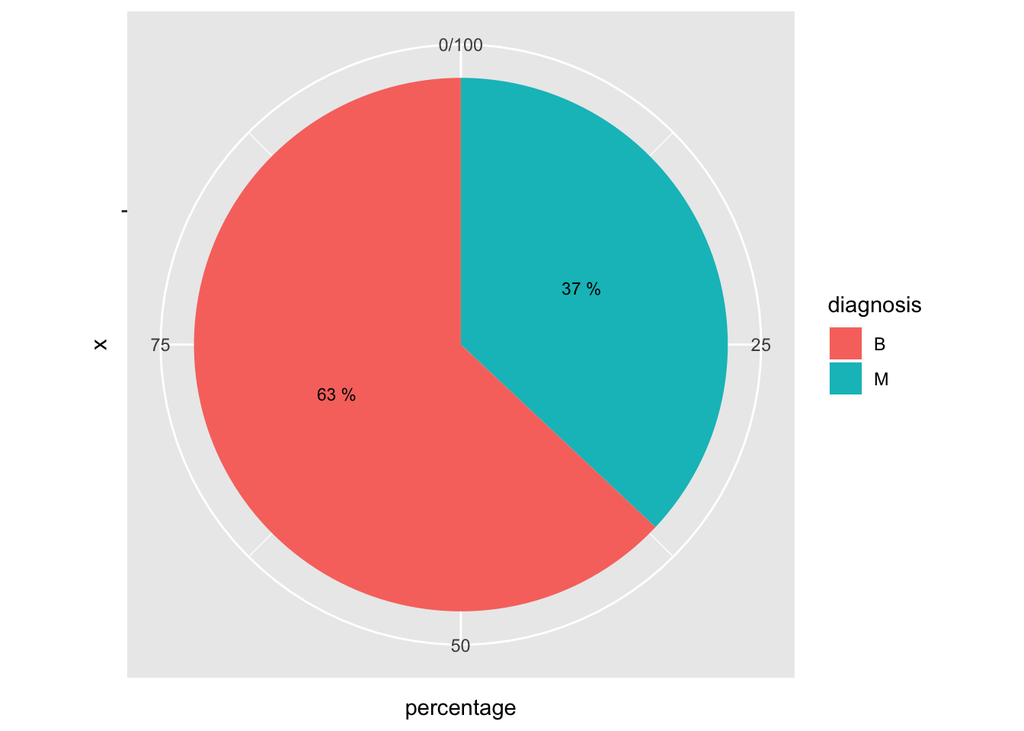

```r
# Malignant and Benign Distribution
m_and_b <- bc.clean %>%
  group_by(diagnosis) %>%
  summarise(n = n()) %>%
  mutate(percentage = signif((100 * n/sum(n)),2))

ggplot(data = m_and_b) +
  geom_bar(
    mapping = aes(x = "",y = percentage, fill = diagnosis),
    stat = "identity",
    width = 1) +
  geom_text(
    mapping = aes(x = c(1,1), y = c(69,18),
                  label = paste(percentage,"%")),
    size = 3) +
  coord_polar("y")
```

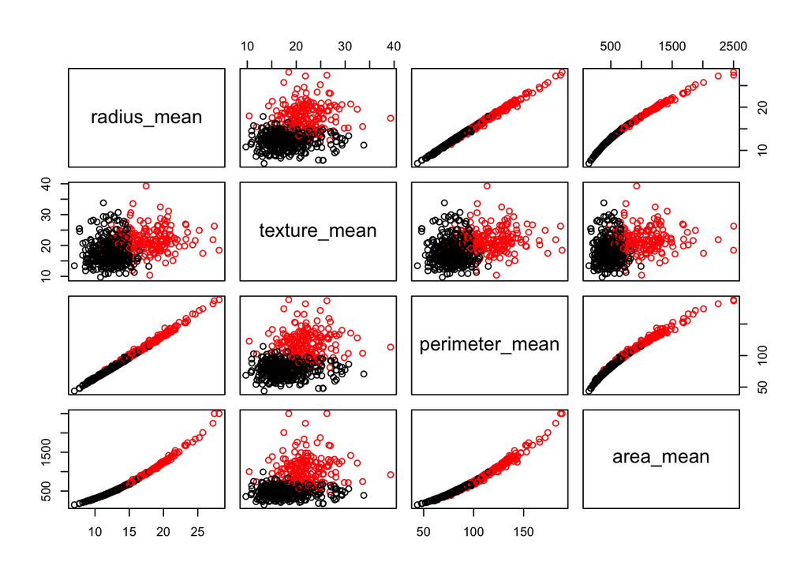

```r
#Scatter plots color coded by response for just the first few variables
pairs(bc[,3:6],col=bc$diagnosis)
```

```r
# ADDING BOX PLOT VISUALS

#Box Plot: Perimeter Mean
# boxplot(perimeter_mean ~ diagnosis,data=wdbc,
# horizontal=TRUE,
# names=c("Benign","Malignant"),
# col=c("green","red"),
# xlab="Perimeter Mean",
# main="Wisconsin Breast Cancer")
#
# #Box Plot: Area Mean
# boxplot(area_mean ~ diagnosis,data=wdbc,
# horizontal=TRUE,
# names=c("Benign","Malignant"),
# col=c("green","red"),
# xlab="Area Mean",
# main="Wisconsin Breast Cancer")
#
# #Box Plot: Radius Mean
# boxplot(radius_mean ~ diagnosis,data=wdbc,
# horizontal=TRUE,
# names=c("Benign","Malignant"),
# col=c("green","red"),
# xlab="Radius Mean",
# main="Wisconsin Breast Cancer")
```

So we can see from this pairs plot of just the first few variables, seperation between the cancer and non cancer groups are pretty well seperated. Unfortunately we may not always see clear seperations but that does not necesarily mean that something like LDA or some other predcictive tool won’t work. It could be due to the fact we cant see the seperation of the groups unless we can actually see in higher dimensions. One way to still get at this, is to conduct a PCA analysis and provide a some scatterplots for the first few PC’s. If seperation exists in the PC’s, then a predictive model will probably do well.

Below we will conduct PCA on all of the predictors and plot the first few PC’s against each other and look for speration. The number of PCs to explore can be dictated by the scree plot.

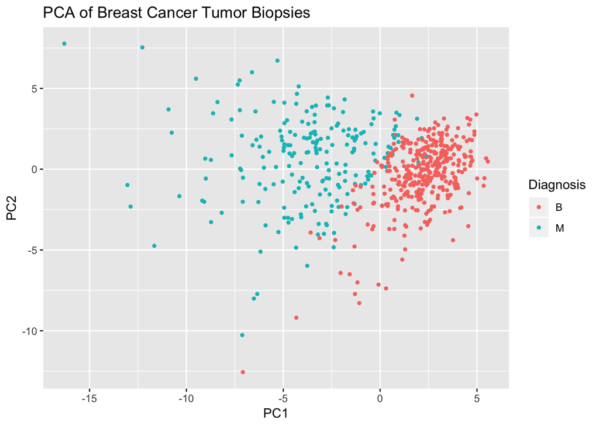

```r
pc.bc<-prcomp(bc[,-c(1,2)],scale.=TRUE)
pc.bc.scores<-pc.bc$x

#Adding the response column to the PC's data frame
pc.bc.scores<-data.frame(pc.bc.scores)
pc.bc.scores$Diagnosis<-bc$diagnosis

#Use ggplot2 to plot the first few pc's
library(ggplot2)
ggplot(data = pc.bc.scores, aes(x = PC1, y = PC2)) +
  geom_point(aes(col=Diagnosis), size=1)+
  ggtitle("PCA of Breast Cancer Tumor Biopsies")
```

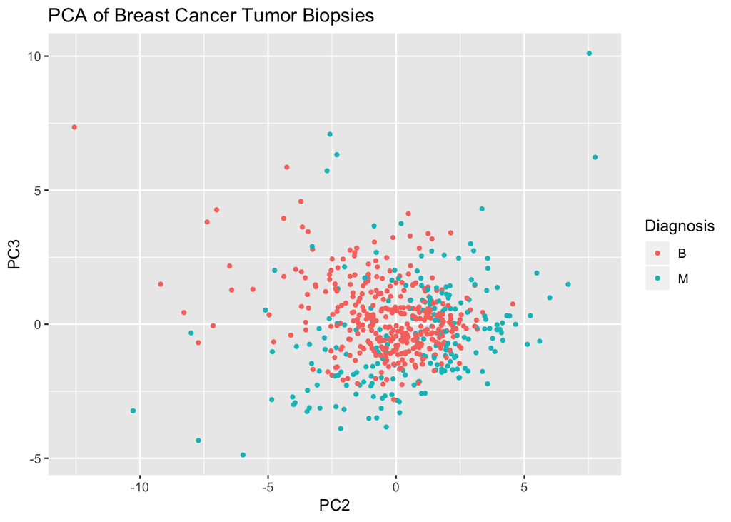

```r
ggplot(data = pc.bc.scores, aes(x = PC2, y = PC3)) +
  geom_point(aes(col=Diagnosis), size=1)+
  ggtitle("PCA of Breast Cancer Tumor Biopsies")
```

So we can see in the first graphic a clear seperation exists for the two cancer groups. So the PCA is telling us in effect what we already know from looking at the original variables. The power of this approach is that you only need to look at 2-4 graphs each time, versus potentially having to examine massive scatterplot matrices to see if anything is there or not!

```r
library(MASS)
# Perform LDA on diagnosis
mylda <- lda(Diagnosis ~ PC1 + PC2 + PC3 + PC4 + PC5 + PC6, data = pc.bc.scores)

#confusion matrix
prd<-predict(mylda, newdata = pc.bc.scores)$class
table(prd,pc.bc.scores$Diagnosis)
```

```
##
## prd   B   M
##   B 356  27
##   M   1 185
```

Seeing how a lot of the attributes are strongly correlated, we will use PCA to convert attributes into a set of uncorrelated components.

Conduct PCA

```r
pca_wdbc <- princomp(bc.clean.normalized[,-c(1)]) # PCA on attributes
pc_wdbc <- pca_wdbc$scores # PCA scores
pc_wdbc_c <- bc$diagnosis # WDBC class attribute
```

Adding the response column to the PC’s data frame

```r
full_wdbc <- data.frame(pc_wdbc,pc_wdbc_c) # Combining PC with class attribute
```

Use ggplot2 to plot the first few pc’s

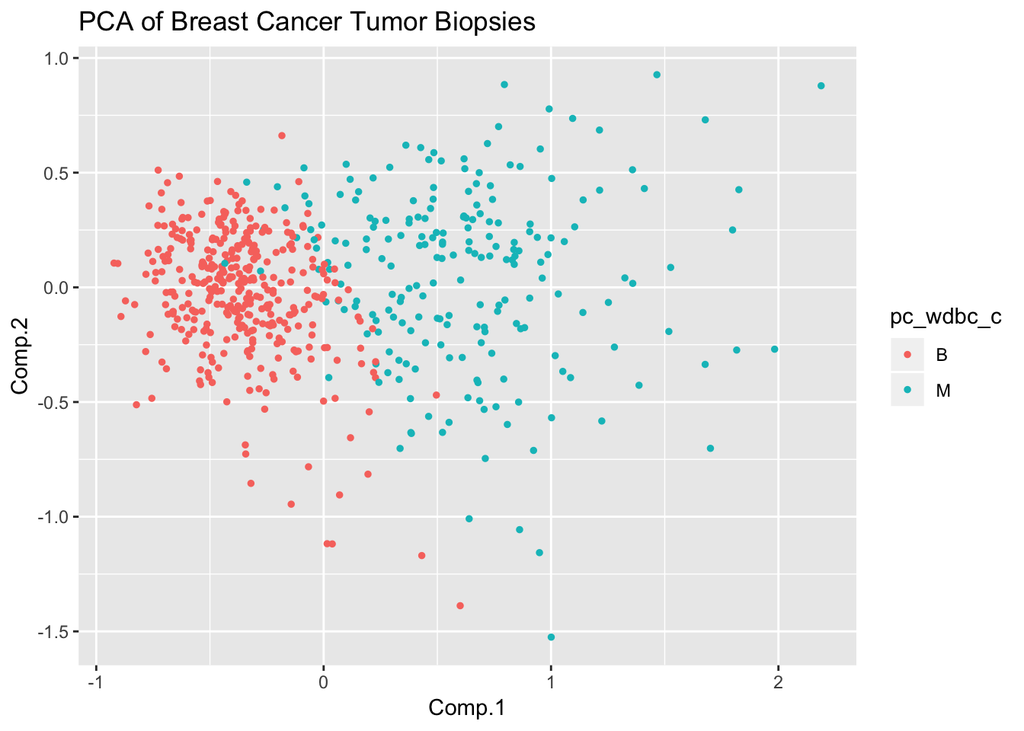

```r
library(ggplot2)
ggplot(data = full_wdbc, aes(x = Comp.1, y = Comp.2)) +
  geom_point(aes(col=pc_wdbc_c), size=1)+
  ggtitle("PCA of Breast Cancer Tumor Biopsies")
```

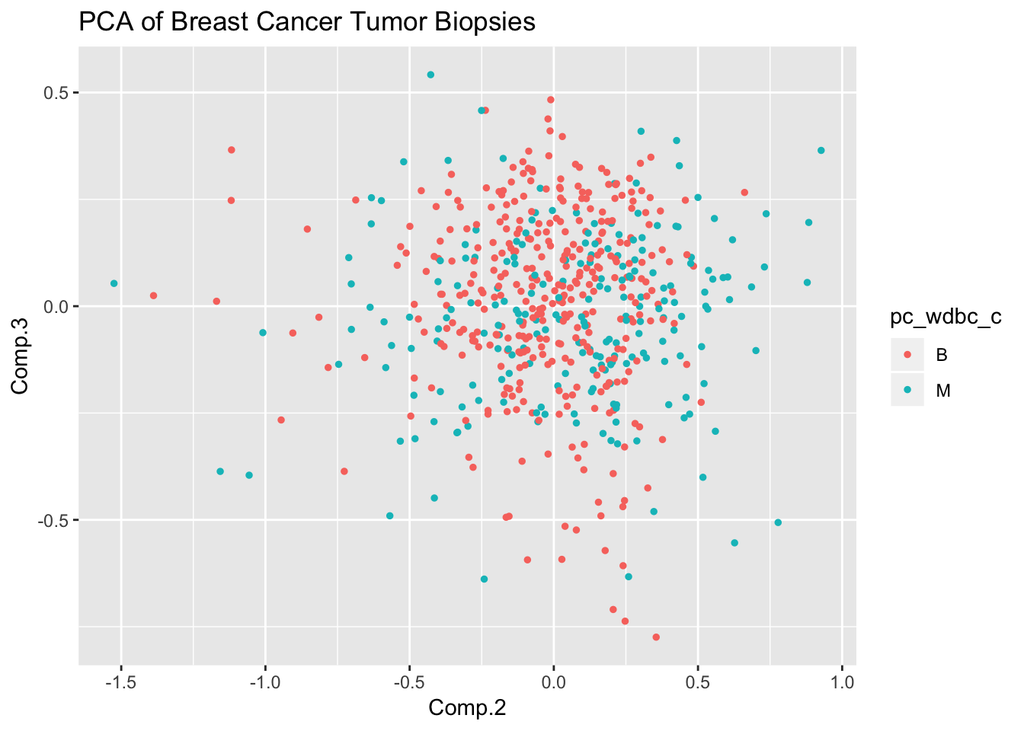

```r
ggplot(data = full_wdbc, aes(x = Comp.2, y = Comp.3)) +
  geom_point(aes(col=pc_wdbc_c), size=1)+
  ggtitle("PCA of Breast Cancer Tumor Biopsies")
```

```r
summary(pca_wdbc)
```

```
## Importance of components:
##                           Comp.1    Comp.2     Comp.3     Comp.4
## Standard deviation     0.5751101 0.3281171 0.21051526 0.19984110
## Proportion of Variance 0.5309769 0.1728349 0.07114442 0.06411259
## Cumulative Proportion  0.5309769 0.7038118 0.77495621 0.83906880
##                            Comp.5     Comp.6     Comp.7     Comp.8
## Standard deviation     0.15953874 0.13832097 0.09923315 0.08614995
## Proportion of Variance 0.04086072 0.03071494 0.01580837 0.01191472
## Cumulative Proportion  0.87992952 0.91064446 0.92645284 0.93836755
##                             Comp.9     Comp.10     Comp.11     Comp.12
## Standard deviation     0.078466796 0.076741723 0.072739180 0.068713333
## Proportion of Variance 0.009884291 0.009454461 0.008493966 0.007579765
## Cumulative Proportion  0.948251845 0.957706306 0.966200271 0.973780036
##                            Comp.13     Comp.14     Comp.15     Comp.16
## Standard deviation     0.063955251 0.054384326 0.040966679 0.040069717
## Proportion of Variance 0.006566381 0.004748115 0.002694233 0.002577545
## Cumulative Proportion  0.980346417 0.985094532 0.987788765 0.990366310
##                            Comp.17     Comp.18     Comp.19     Comp.20
## Standard deviation     0.033832449 0.030696718 0.029289317 0.025691093
## Proportion of Variance 0.001837556 0.001512717 0.001377185 0.001059592
## Cumulative Proportion  0.992203866 0.993716583 0.995093767 0.996153360
##                            Comp.21      Comp.22    Comp.23      Comp.24
## Standard deviation     0.024745908 0.0221059201 0.01813656 0.0178234826
## Proportion of Variance 0.000983061 0.0007844963 0.00052806 0.0005099867
## Cumulative Proportion  0.997136421 0.9979209169 0.99844898 0.9989589637
##                             Comp.25      Comp.26     Comp.27      Comp.28
## Standard deviation     0.0163675776 0.0143290755 0.010895447 5.901461e-03
## Proportion of Variance 0.0004300733 0.0003296173 0.000190574 5.591043e-05
## Cumulative Proportion  0.9993890370 0.9997186543 0.999909228 9.999651e-01
##                             Comp.29      Comp.30
## Standard deviation     4.242650e-03 1.927531e-03
## Proportion of Variance 2.889669e-05 5.964532e-06
## Cumulative Proportion  9.999940e-01 1.000000e+00
```

```r
library(factoextra)
```

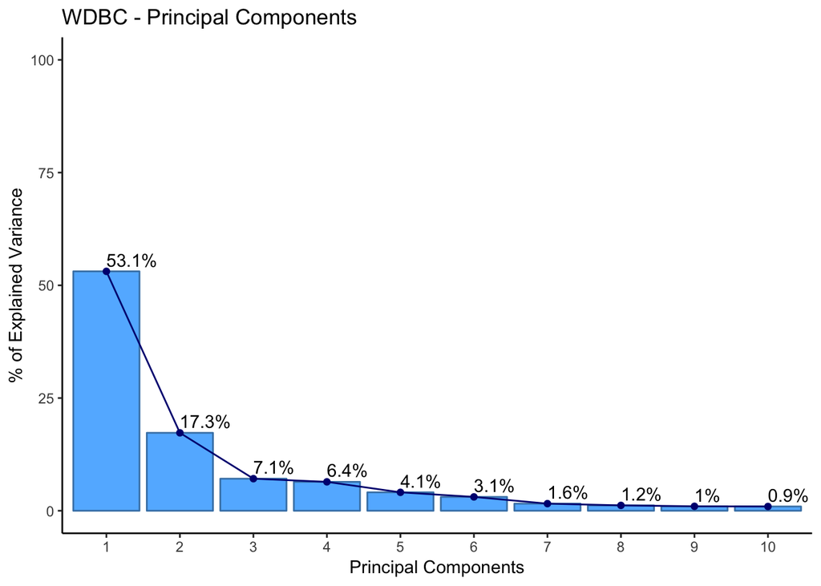

```r
fviz_eig(pca_wdbc, addlabels = TRUE, ylim = c(0,100), barfill = "steelblue1", line="navy") +
  theme_classic() +
  labs(x = "Principal Components", y = "% of Explained Variance", title = "WDBC - Principal Components")
```

```r
# We see that 53.1% of the variance is explained by the first principal component.
```

Model Creation:

Models will be created using 5-fold cross-validation, given the relatively small sample size of the dataset. Setting parameters below:

Setting up 5-fold cross-validation:

```r
ctrl <- trainControl(method = "cv",
                     number = 5)
```

Function for plotting confusion matrices

```r
cm_plot <- function(ml, title) {
  confusionMatrix(ml)$table %>%
    round(1) %>%
    fourfoldplot(
      color = c("#CC6666", "#99CC99"),
      main=title,
      conf.level=0,
      margin=1
    )
}
```

Logistic Regression:

```r
logit.ml <- train(pc_wdbc_c~., full_wdbc, method = "glm", family = "binomial", trControl =ctrl)
```

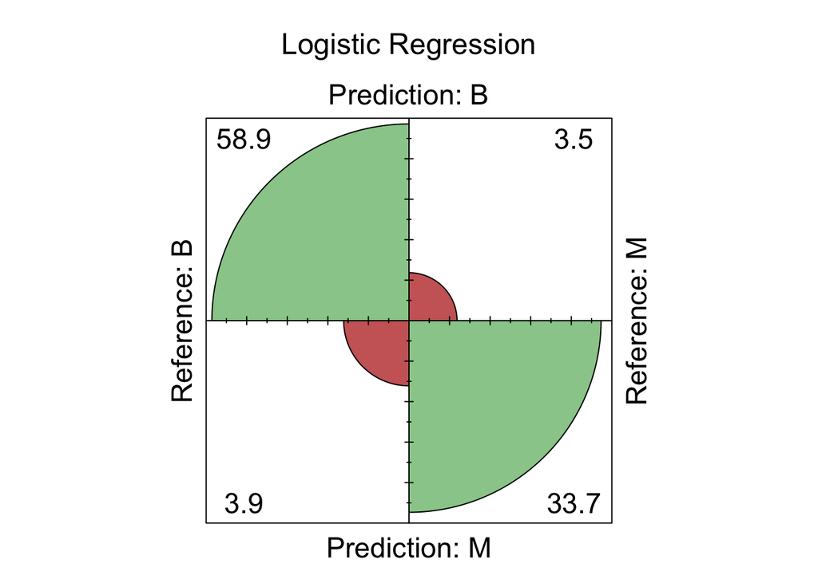

```r
logit.cm <- confusionMatrix(logit.ml)
cm_plot(logit.ml, "Logistic Regression")
```

```r
logit.metrics <- data.frame (
  "Model" = "Logistic Regression",
  "Accuracy" = (logit.cm$table[1,1] + logit.cm$table[2,2])/100,
  "Recall" = logit.cm$table[2,2] / (logit.cm$table[2,2] + logit.cm$table[1,2]),
  "Precision" = logit.cm$table[2,2] / (logit.cm$table[2,1] + logit.cm$table[2,2]),
  "FNR" = (logit.cm$table[1,2] / (logit.cm$table[2,2] + logit.cm$table[1,2])),
  "Fscore" = (2 * logit.cm$table[2,2]) / (2 * logit.cm$table[2,2] + logit.cm$table[1,2] + logit.cm$table[2,1])
)
logit.metrics
```

```
##                 Model  Accuracy    Recall Precision        FNR    Fscore
## 1 Logistic Regression 0.9261863 0.9056604 0.8971963 0.09433962 0.9014085
```

k-Nearest Neighbours:

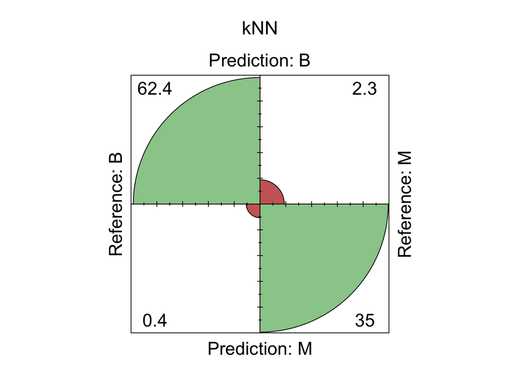

```r
knn.ml <- train(pc_wdbc_c~., full_wdbc, method = "knn", trControl =ctrl)
knn.cm <- confusionMatrix(knn.ml)
cm_plot(knn.ml, "kNN")
```

```r
knn.metrics <- data.frame (
  "Model" = "k-NN",
  "Accuracy" = (knn.cm$table[1,1] + knn.cm$table[2,2])/100,
  "Recall" = knn.cm$table[2,2] / (knn.cm$table[2,2] + knn.cm$table[1,2]),
  "Precision" = knn.cm$table[2,2] / (knn.cm$table[2,1] + knn.cm$table[2,2]),
  "FNR" = (knn.cm$table[1,2] / (knn.cm$table[2,2] + knn.cm$table[1,2])),
  "Fscore" = (2 * knn.cm$table[2,2]) / (2 * knn.cm$table[2,2] + knn.cm$table[1,2] + knn.cm$table[2,1])
)
knn.metrics
```

```
##   Model Accuracy    Recall Precision        FNR    Fscore
## 1  k-NN 0.973638 0.9386792 0.9900498 0.06132075 0.9636804
```

Random Forest:

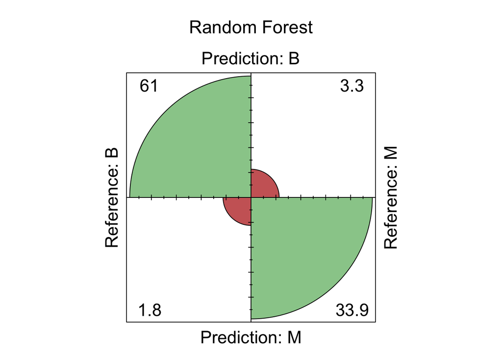

```r
rf.ml <- train(pc_wdbc_c~., full_wdbc, method = "rf", trControl =ctrl)
rf.cm <- confusionMatrix(rf.ml)
cm_plot(rf.ml, "Random Forest")
```

```r
rf.metrics <- data.frame (
  "Model" = "Random Forest",
  "Accuracy" = (rf.cm$table[1,1] + rf.cm$table[2,2])/100,
  "Recall" = rf.cm$table[2,2] / (rf.cm$table[2,2] + rf.cm$table[1,2]),
  "Precision" = rf.cm$table[2,2] / (rf.cm$table[2,1] + rf.cm$table[2,2]),
  "FNR" = (rf.cm$table[1,2] / (rf.cm$table[2,2] + rf.cm$table[1,2])),
  "Fscore" = (2 * rf.cm$table[2,2]) / (2 * rf.cm$table[2,2] + rf.cm$table[1,2] + rf.cm$table[2,1])
)
rf.metrics
```

```
##           Model  Accuracy    Recall Precision        FNR    Fscore
## 1 Random Forest 0.9490334 0.9103774 0.9507389 0.08962264 0.9301205
```

Model Performance - Confusion Matrices:

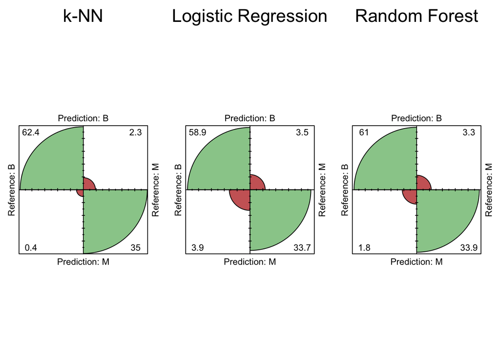

```r
#Take a look at all confusion matrices:
par(mfrow=c(1,3))
cm_plot(knn.ml, "k-NN")
cm_plot(logit.ml, "Logistic Regression")
cm_plot(rf.ml, "Random Forest")
```

Model Performance - Metrics:

```r
metrics1 <- rbind(knn.metrics,logit.metrics, rf.metrics)
metrics1 # Taking a look at everything together
```

```
##                 Model  Accuracy    Recall Precision        FNR    Fscore
## 1                k-NN 0.9736380 0.9386792 0.9900498 0.06132075 0.9636804
## 2 Logistic Regression 0.9261863 0.9056604 0.8971963 0.09433962 0.9014085
## 3       Random Forest 0.9490334 0.9103774 0.9507389 0.08962264 0.9301205
```

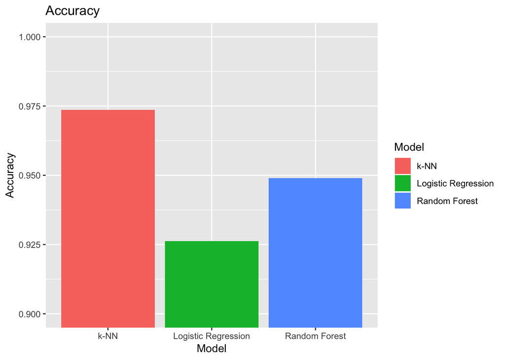

```r
ggplot(metrics1, aes(Model, Accuracy)) + geom_bar(stat="identity", aes(fill=Model)) + coord_cartesian(ylim=c(0.9,1)) + ggtitle("Accuracy")
```

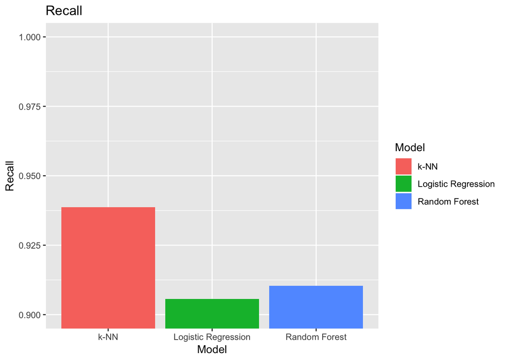

```r
ggplot(metrics1, aes(Model, Recall)) + geom_bar(stat="identity", aes(fill=Model)) + coord_cartesian(ylim=c(0.9,1)) + ggtitle("Recall")
```

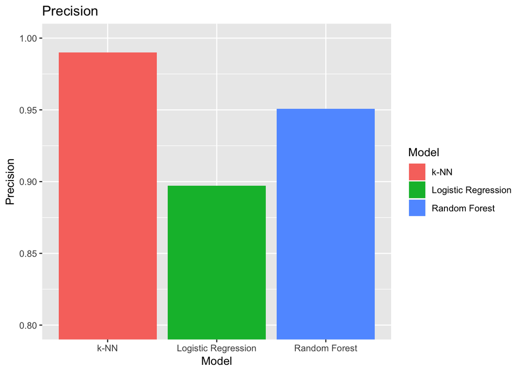

```r
ggplot(metrics1, aes(Model, Precision)) + geom_bar(stat="identity", aes(fill=Model)) + coord_cartesian(ylim=c(0.8,1)) + ggtitle("Precision")
```

[figure not shown]

```r
ggplot(metrics1, aes(Model, FNR)) + geom_bar(stat="identity", aes(fill=Model)) + coord_cartesian(ylim=c(0,0.05)) + ggtitle("False Negative Rate")
```

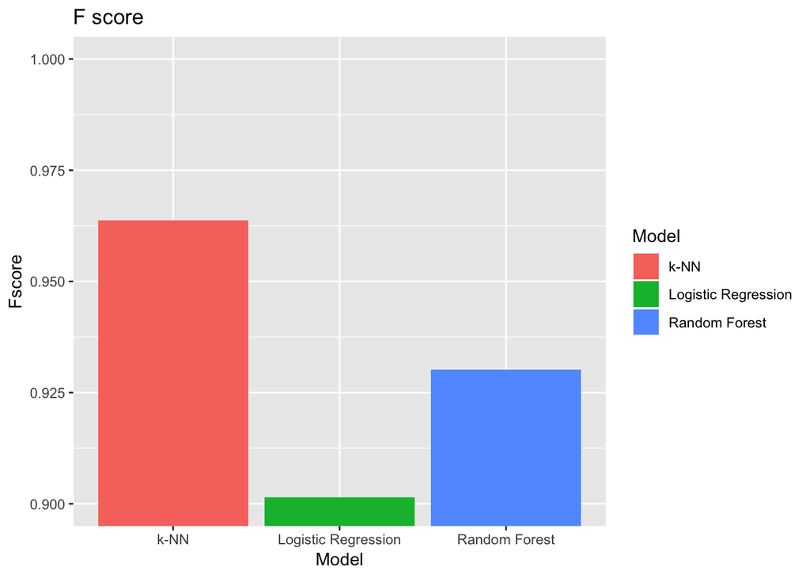

```r
ggplot(metrics1, aes(Model, Fscore)) + geom_bar(stat="identity", aes(fill=Model)) + coord_cartesian(ylim=c(0.9,1)) + ggtitle("F score")
```